# Course Project Practical Machine Learning

E. Kloos

21 oktober 2018

## Introduction

Using devices such as Jawbone Up, Nike FuelBand, and Fitbit it is now possible to collect a large amount of data about personal activity relatively inexpensively. These type of devices are part of the quantified self movement - a group of enthusiasts who take measurements about themselves regularly to improve their health, to find patterns in their behavior, or because they are tech geeks. One thing that people regularly do is quantify how much of a particular activity they do, but they rarely quantify how well they do it. In this project 6 particitpants were asked to perform barbell lifts in 5 different ways where they were asked to ghe excercse in certain sets correctly and others incorrectly. Or goal is to make a model that can classify from the data if a set barbell lift was done corrclt or incorreclty. The data we have is from accelerometers on the belt, forearm, arm, and dumbell. (For more information on where the data came from please visit http://web.archive.org/web/20161224072740/http:/groupware.les.inf.puc-rio.br/har).

**Bellow we find all packages that we will use during this project.**

```r
library(rattle)
```

```r
library(corrplot)
library(caret)
```

## Collecting and examening the data

First we will collect the data get a overview of how the data looks like.

```r
training <- read.csv("~/pml-training.csv")
testing_org <- read.csv("~/pml-testing.csv")
#We see that the testset only has 20 observations. Compared to the training set, this is a too small sample.
#We will therefor create our own training set.

set.seed(333)
train_index <- createDataPartition(training$classe, p = 0.70, list = FALSE)
training <- training[train_index,]
testing <- training[-train_index,]

dim(training)
```

```
## [1] 13737   160
```

The training set consits of 13737 observations with 160 variables. The variable we want to predict is the ‘class’ variable.

```r
summary(training$classe)
```

```
##    A    B    C    D    E
## 3906 2658 2396 2252 2525
```

We see that there are 5 groups that can be classified.

## Preprocessing

Because of the high dimensionalilty of out dataset there is a chance we will run into models with very high complexity. We there for will first examin if there are variables that have near zero varaince, and remove these form out data. Furthermore we will remove variables that are for the most part NA values and are identification varialbes (these variables do not give any extra prediciton power).

```r
#Remove near zero values
nzv <- nearZeroVar(training)
training <- training[,-nzv]
testing <- testing[, -nzv]

#remove variables with a lot of NA values
variables_na <- sapply(training, function(x) mean(is.na(x))) > 0.95
training <- training[, !variables_na]
testing <- testing[, !variables_na]

#remove identification variables
training <- training[,-(1:5)]
testing <- testing[,-(1:5)]

dim(training)
```

```
## [1] 13737    54
```

Now that we have removed variables that will not add a lot of prediction power because of low variance and/or are mostly NA values, we will examin the correlation between variables.

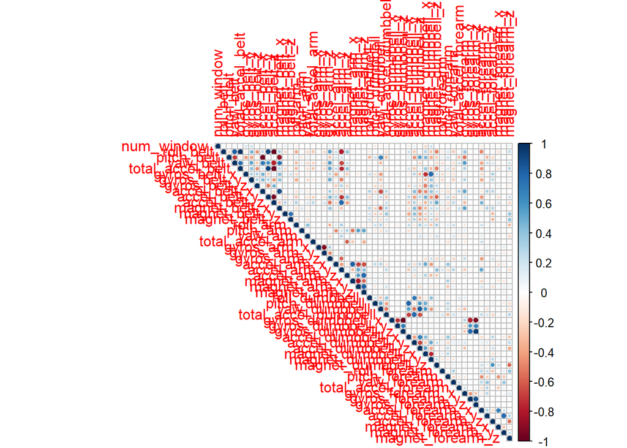

```r
cor_matrix <- cor(training[,-54])
corrplot(cor_matrix, type="upper")
```

Wee se that most variables do not have a lot of correlation wih each other. We do see a few clusters of cariables that are correlated, but because these are so few, there is no gain in further dimensionality reduction/preprocessing.

## Creating models

For this problem we will build multiple models so that we ca compare them to each other. We will take the following models:

- Decision tree
- Random Forrest
- Boosting tree

#### Decision Tree

```r
time1 <- system.time(mod1 <- train(classe ~. , data = training, method = "rpart"))
time1
```

```
##    user  system elapsed
##    8.80    0.33    9.12
```

We take a look at the tree

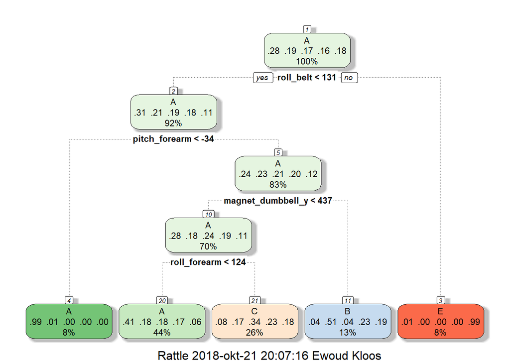

```r
fancyRpartPlot(mod1$finalModel)
```

From this plot we see that the first node was from the variable **roll_belt** with a split at value 131. This varaible has apparently the most information gain.

#### Random Forrest

```r
time2 <- system.time(mod2 <- train(classe ~. , data = training, method = "rf"))
time2
```

```
##    user  system elapsed
## 2453.34   11.44 2465.73
```

#### Boosted tree

```r
time3 <- system.time(mod3 <- train(classe ~. , data =  training, method = "gbm"))
time3
```

```
##    user  system elapsed
## 1053.82    2.35 1056.69
```

## Evaluation

We will now see ho well the models preform. We will look at there in sample and out of sample performance.

```r
pred1_in <- predict(mod1, training)
pred2_in <- predict(mod2, training)
pred3_in <- predict(mod3, training)

pred1_out <- predict(mod1, testing)
pred2_out <- predict(mod2, testing)
pred3_out <- predict(mod3, testing)


confusion_pred1_in <- confusionMatrix(pred1_in, training$classe)
confusion_pred2_in <- confusionMatrix(pred2_in, training$classe)
confusion_pred3_in <- confusionMatrix(pred3_in, training$classe)

confusion_pred1_out <- confusionMatrix(pred1_out, testing$classe)
confusion_pred2_out <- confusionMatrix(pred2_out, testing$classe)
confusion_pred3_out <- confusionMatrix(pred3_out, testing$classe)
```

#### In sample Accuracy

[figure not shown]

```r
par(mfrow=c(1,3))
plot(confusion_pred1_in$table, main = paste("Model 1 - Decision Tree - Accuracy "
                                            , round(confusion_pred1_in$overall[["Accuracy"]], 3)))
plot(confusion_pred2_in$table, main = paste("Model 2 - Random Forest - Accuracy "
                                            , round(confusion_pred2_in$overall[["Accuracy"]], 3)))
plot(confusion_pred2_in$table, main = paste("Model 3 - Boosted Tree - Accuracy "
                                            , round(confusion_pred3_in$overall[["Accuracy"]], 3)))
```

[figure not shown]

```r
par(mfrow=c(1,3))
plot(confusion_pred1_out$table, main = paste("Model 1 - Decision Tree - Accuracy "
                                            , round(confusion_pred1_out$overall[["Accuracy"]], 3)))
plot(confusion_pred2_out$table, main = paste("Model 2 - Random Forest - Accuracy "
                                            , round(confusion_pred2_out$overall[["Accuracy"]], 3)))
plot(confusion_pred2_out$table, main = paste("Model 3 - Boosted Tree - Accuracy "
                                            , round(confusion_pred3_out$overall[["Accuracy"]], 3)))
```